# Baby Name Trends

September 15, 2016

## Load Packages & Data

Run the block of code below only once. Notes:

- Hashtags in R are comment lines that are ignored by the console. This is a great way to document your code
  - For others, but more importantly
  - Future you! Hadley Wickham quote: “In every project you have at least one other collaborator; future-you. You don’t want future-you to curse past-you”
- You do not need to completely understand the code below for now; we’ll be learning these packages in the upcoming weeks.
- In case you are curious however, after loading the packages, we need to adjust for the fact that names that occurred less than 5 times for any sex for any given year were excluded from the data set. We create a new category `Other` to reflect this.

```r
# Load packages
library(ggplot2)
library(dplyr)
library(babynames)

# Compute counts/proporations for "Other" names
other <- babynames %>%
  group_by(year, sex) %>%
  summarise(sum_n=sum(n), sum_prop=sum(prop)) %>%
  mutate(
    total = sum_n/sum_prop,
    name = "Other",
    prop = 1-sum_prop,
    n = prop * total
    ) %>%
  select(year, sex, name, n, prop)

# Add "Other" names to babynames
babynames <- babynames %>%
  bind_rows(other) %>%
  arrange(year, sex, desc(n))
```

## Explore Data Set

Play around with the `babynames` dataset in the RStudio viewer by running the following in the console.

```r
View(babynames)
```

In particular, click on the **Filter** button and click in the white boxes under the variable names and

- Play with any sliders for numerical variables: year, n, prop
- Enter in values to view subsets of rows: sex, name

## Name Trends

The code below shows the popularity trend for the name “Jeffrey” amongst males. Switch the name/sex variable values that get assigned and explore the popularity of different names.

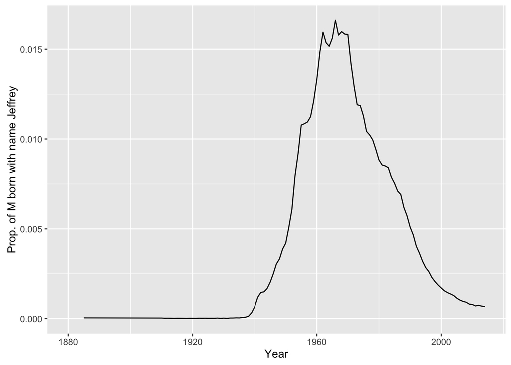

```r
baby_name <- "Jeffrey"
baby_sex <- "M"

single_name <- babynames %>%
  filter(name==baby_name & sex==baby_sex)

ggplot(data=single_name, mapping = aes(x=year, y=prop)) +
  geom_line() +
  xlim(c(1880, 2014)) +
  ylim(c(0, NA)) +
  xlab("Year") +
  ylab(paste("Prop. of ", baby_sex, " born with name ", baby_name, sep=""))
```